# Übung B Koordinatensysteme

RaumAn1

Patrick Laube , Nils Ratnaweera , Nikolaos Bakogiannis  
10-26-2021

### Aufgabe 1: Koordinatensysteme *zuweisen*

In der letzten Aufgabe habt ihr `kantone.gpkg` und `bezirke.gpgk` runtergeladen, importiert und visualisiert.

[figure not shown]

[figure not shown]

```r
library(sf)
library(ggplot2)

kantone <- read_sf("kantone.gpkg")
bezirke <- read_sf("bezirke.gpkg")
```

Dabei fällt folgendes auf:

- die X/Y Achsen weisen zwei ganz unterschiedlichen Zahlenbereiche auf (vergleiche die Achsenbeschriftungen)
- der Umriss der Schweiz sieht in den beiden Datensätzen unterschiedlich aus (`kantone` ist gegenüber `bezirke` gestaucht)

Dies hat natürlich damit zu tun, dass die beiden Datensätze in unterschiedlichen Koordinatensystemen erfasst wurden. Koordinatensysteme werden mit CRS (**C**oordinate **R**eference **S**ystem) abgekürzt. Mit `st_crs()` könnnen die zugewiesenen Koordinatensysteme abgefragt werden.

```r
st_crs(kantone)
```

```
Coordinate Reference System: NA
```

```r
st_crs(bezirke)
```

```
Coordinate Reference System: NA
```

Leider sind in unserem Fall keine Koordinatensysteme zugewiesen. Mit etwas Erfahrung kann man das Koordinatensystem aber erraten, so viele kommen nämlich gar nicht in Frage. Am häufigsten trifft man hierzulande eines der drei folgenden Koordinatensysteme an:

- [CH1903 LV03](https://epsg.io/21781): das alte Koordinatensystem der Schweiz
- [CH1903+ LV95](https://epsg.io/2056): das neue Koordinatensystem der Schweiz
- [WGS84](https://epsg.io/4326): ein häufig genutztes weltumspannendes geodätisches Koordinatensystem, sprich die Koordinaten werden in Länge und Breite angegeben (Lat/Lon).

**Bedienungshinweise**:

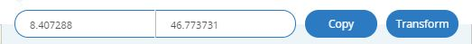

Koordinanten (des Fadenkreuzes) werden im ausgewählten Koordinatensystem dargestellt

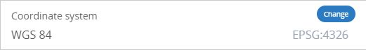

Das Koordinatensystem, in welchem die Koordinaten dargestellt werden sollen, kann mit “Change” angepasst werden

Für Enthusiasten: Schau Dir die Schweiz in verschiedenen Koordinatensystemen an, in dem Du auf “Reproject Map” klickst

Wenn man diese Koordinaten mit den Koordinaten unserer Datensätze vergleicht, dann ist schnell klar, dass es sich beim Datensatz `kantone` um das Koordinatensystem WGS84 handelt und bei `bezirke` das Koordinatensystem CH1903+ LV95. Diese Koordinatensyteme weisen wir nun mit `st_set_crs()` und dem entsprechenden *EPSG*-Code (siehe die jeweiligen Links) zu.

```r
kantone <- st_set_crs(kantone, 4326)
bezirke <- st_set_crs(bezirke, 2056)

# zuweisen mit st_set_crs(), abfragen mit st_crs()
st_crs(kantone)
```

```
Coordinate Reference System:
  User input: EPSG:4326
  wkt:
GEOGCRS["WGS 84",
    DATUM["World Geodetic System 1984",
        ELLIPSOID["WGS 84",6378137,298.257223563,
            LENGTHUNIT["metre",1]]],
    PRIMEM["Greenwich",0,
        ANGLEUNIT["degree",0.0174532925199433]],
    CS[ellipsoidal,2],
        AXIS["geodetic latitude (Lat)",north,
            ORDER[1],
            ANGLEUNIT["degree",0.0174532925199433]],
        AXIS["geodetic longitude (Lon)",east,
            ORDER[2],
            ANGLEUNIT["degree",0.0174532925199433]],
    USAGE[
        SCOPE["Horizontal component of 3D system."],
        AREA["World."],
        BBOX[-90,-180,90,180]],
    ID["EPSG",4326]]
```

Jetzt wo das CRS der Datensätze bekannt ist, können diese in einem gemeinsamen Plot visualisiert werden, `ggplot` kümmert sich darum die unterschiedlichen Koordinatensysteme zu vereinheitlichen. Probier das aus, indem du `kantone` und `bezirke` in einem `ggplot` kombinierst.

Die Achsen werden dann immer in WGS84 beschriftet. Wenn das stört, kann man `coord_sf(datum = 2056)` in einem weiteren Layer spezifizieren. Oder aber man blendet die Achsenbeschriftung mit `theme_void()` komplett aus. Versuche beide Varianten.

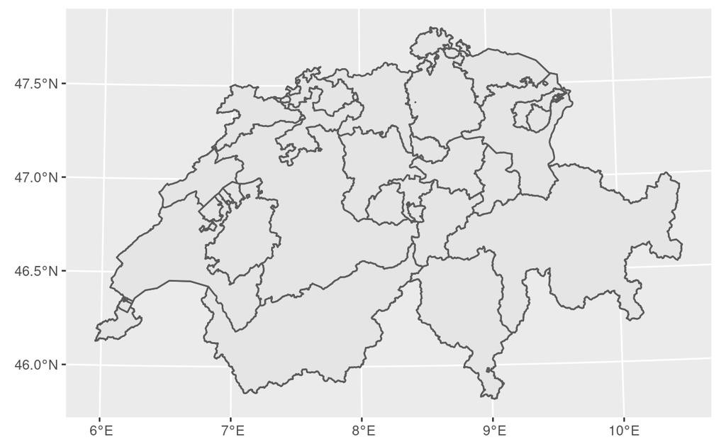

```r
ggplot() +
  geom_sf(data = bezirke) +
  geom_sf(data = kantone)
```

### Aufgabe 2: Koordinatensyteme *transformieren*

In der vorherigen Übung haben wir das bestehende Koordinatensystem *zugewiesen*. Dabei haben wir die bestehenden Koordinaten (in der Spalte `geom`) *nicht* manipuliert. Ganz anders ist eine *Transformation* der Daten von einem Koordinatensystem in das andere. Bei einer Transformation werden die Koordinaten in das neue Koordinatensystem umgerechnet und somit manipuliert. Aus praktischen Gründen wollen wir all unsere Daten ins neue Schweizer Koordinatensystem CH1903+ LV95 transfomieren. Transformiere den Datensatz `kantone` mit `st_transform()`in CH1903+ LV95, nutze dafür den korrekten EPSG-Code.

Vor der Transformation (betrachte die Attribute `Bounding box` sowie `Geodetic CRS`):

```r
kantone
```

```
Simple feature collection with 51 features and 6 fields
Geometry type: POLYGON
Dimension:     XY
Bounding box:  xmin: 5.955902 ymin: 45.81796 xmax: 10.49217 ymax: 47.80845
Geodetic CRS:  WGS 84
# A tibble: 51 × 7
   NAME            KANTONSNUM SEE_FLAECH KANTONSFLA KT_TEIL EINWOHNERZ
 * <chr>                <dbl>      <dbl>      <dbl> <chr>        <dbl>
 1 Aargau                  19        870     140380 1           685845
 2 Aargau                  19         NA         NA 2               NA
 3 Appenzell Auss…         15         NA      24284 0            55445
 4 Appenzell Inne…         16         NA      17248 1            16128
 5 Appenzell Inne…         16         NA         NA 2               NA
 6 Appenzell Inne…         16         NA         NA 3               NA
 7 Appenzell Inne…         16         NA         NA 4               NA
 8 Appenzell Inne…         16         NA         NA 5               NA
 9 Basel-Landscha…         13         NA      51767 1           289468
10 Basel-Landscha…         13         NA         NA 2               NA
# … with 41 more rows, and 1 more variable: geom <POLYGON [°]>
```

```r
kantone <- st_transform(kantone, 2056)
```

Nach der Transformation (betrachte die Attribute `Bounding box` sowie `Projected CRS`):

```r
kantone
```

```
Simple feature collection with 51 features and 6 fields
Geometry type: POLYGON
Dimension:     XY
Bounding box:  xmin: 2485410 ymin: 1075268 xmax: 2833858 ymax: 1295934
Projected CRS: CH1903+ / LV95
# A tibble: 51 × 7
   NAME            KANTONSNUM SEE_FLAECH KANTONSFLA KT_TEIL EINWOHNERZ
 * <chr>                <dbl>      <dbl>      <dbl> <chr>        <dbl>
 1 Aargau                  19        870     140380 1           685845
 2 Aargau                  19         NA         NA 2               NA
 3 Appenzell Auss…         15         NA      24284 0            55445
 4 Appenzell Inne…         16         NA      17248 1            16128
 5 Appenzell Inne…         16         NA         NA 2               NA
 6 Appenzell Inne…         16         NA         NA 3               NA
 7 Appenzell Inne…         16         NA         NA 4               NA
 8 Appenzell Inne…         16         NA         NA 5               NA
 9 Basel-Landscha…         13         NA      51767 1           289468
10 Basel-Landscha…         13         NA         NA 2               NA
# … with 41 more rows, and 1 more variable: geom <POLYGON [m]>
```